# Testing the hierarchical reserving models on a simulated portfolio (mixed scenario)

Christophe Nozaradan (extention of a previous version by Jens Robben)

November 2021

## Introduction

This version of this document extends a previous one written by Jens Robben, in which hierarchical GLM and hierarchical GBM are compared in the case of the mixed scenario. In the present version, hierarchical XGB, hierarchical MLP and hierarchical CANN are further considered in the same scenario.

## Simulating the portfolio

The seed number is:

```r
cat(sprintf("%s", seed))
```

```
## 73
```

First, we load the required packages.

```r
require(tidyverse)
require(xgboost)
library(ParBayesianOptimization)
library(doParallel)
require(Matrix)
require(data.table)
require(ggplot2)
require(keras)
require(tensorflow)
require(recipes)
#install.packages('devtools')
#devtools::install_github('cnoza/hirem')
require(hirem)
```

We simulate one portfolio along the mixed claims scenario. The portfolio initially consists of $125\ 000$ claims, but only the claims that are reported between January 1, 2012 and December 31, 2020 are retained. Claims are tracked over 9 development years since reporting. In addition, we create an extra covariate `devYearMonth`, representing a simplified version of the interaction effect between `dev.year` and `rep.month`.

```r
# The complete portfolio
reserving_data <- simulate_scenario_claim_mix(seed = seed, n= 125000)

# We unset the seed
set.seed(NULL)

# Creating the interaction effect
reserving_data$monthDev12 <- as.character(reserving_data$rep.month)
reserving_data$monthDev12[reserving_data$dev.year > 3] <- 'dev.year.over.3'
reserving_data$devYearMonth <- factor(paste(reserving_data$dev.year, reserving_data$monthDev12, sep = '-'))

# Dimension portfolio
dim(reserving_data)
```

```
## [1] 916029     23
```

Next, we set the evaluation date to December 31, 2020. The observed portfolio then consists of the claims that are reported before this evaluation date, i.e. with calendar year before year 9. The prediction data set consists of the remaining claims, namely the claims reported after calendar year 9.

```r
# Observed and prediction data set
observed_data   <- reserving_data %>% filter(calendar.year <= 9)
prediction_data <- reserving_data %>% filter(calendar.year > 9)
```

## Calibration of the hierarhical reserving models

We first define the weights used in the calibration of the hierarchical reserving model. The purpose of these weights is to replicate the development year distribution from the prediction data set to the observed data set (training data set). Hence, more weight is assigned to claims observations in later development years since reporting. We give a very small weight to the claims observations in the first development year since reporting because the prediction data set does not contain observations for this development year. More details are provided in Creveceour, Antonio, and Robben (2021)

```r
# Calculating the weights
reported_claims <- observed_data %>%
  dplyr::filter(dev.year == 1) %>%
  group_by(rep.year) %>%
  dplyr::summarise(count = n()) %>%
  pull(count)

denominator <- tail(rev(cumsum(reported_claims)), -1)
numerator <- head(cumsum(rev(reported_claims)), -1)
weight <- c(10^(-6), numerator / denominator)

names(weight) <- paste0('dev.year',1:9)
weight
```

```
## dev.year1 dev.year2 dev.year3 dev.year4 dev.year5 dev.year6 dev.year7 dev.year8 dev.year9
## 0.0000010 0.1250124 0.2843839 0.4988734 0.8004458 1.2517422 1.9951445 3.5019904 7.8366904
```

### Hierarchical GLM

The hierarchical GLM consists of the three layer structure: settlement, payment and size. We model the settlement indicator using a binomial regression model with a complementary log link function. The payment indicator will be modeled using a logistic regression model and the payment sizes using a Gamma GLM with log-link function.

We define the model specifications of each layer. We only train the reserving model on the claim updates that are still open at the beginning of each year and are observed on the evaluation date (`calendar.year <= 9`).

```r
# Model specifications hierarchical GLM
model_glm  <- hirem(reserving_data) %>%
  split_data(observed = function(df) df %>% filter(calendar.year <= 9, open == 1)) %>%
  layer_glm(name = 'settlement', 'family' = binomial(link = cloglog)) %>%
  layer_glm(name = 'payment', 'family' = binomial(link = logit)) %>%
  layer_glm(name = 'size', 'family' = Gamma(link = 'log'),
            filter = function(x){x$payment == 1})
```

Next, we perform a covariate selection procedure to select the optimal covariates that are retained in the regression models for each layer.

```r
# Covariate selection function
covariate_selection <- function(response_variable, all_covariates, family, data, weight, minimize="deviance") {
  aic_sav <- NULL
  deviance_sav <- NULL
  aic <- c()
  deviance <- c()
  formula_resp_list <- c()
  step <- c()
  i = 1
  covariate_sav_list <- c()
  weights.vec <- weight[data[['dev.year']]]

  while(length(all_covariates) > 0) {
    covariate_sav <- NULL
    for(covariate in all_covariates) {
      cov_list <- append(covariate_sav_list, covariate)
      formula_resp <- as.formula(paste0(response_variable, ' ~ ',paste0(cov_list, collapse = ' + ')))
      m_glm <- glm(formula_resp , family = family, data = data, weights = weights.vec)
      aic <- append(aic, m_glm$aic)
      deviance <- append(deviance, m_glm$deviance)
      formula_resp_list <- append(formula_resp_list, formula_resp)
      step = append(step,i)

      if(is.null(aic_sav)) aic_sav = m_glm$aic + 1
      if(is.null(deviance_sav)) deviance_sav = m_glm$deviance + 1

      if( (m_glm$deviance < deviance_sav & minimize == "deviance")
          | (m_glm$aic < aic_sav & minimize == "aic")) {
        #formula_resp_sav <- formula_resp
        covariate_sav <- covariate
        aic_sav <- m_glm$aic
        deviance_sav <- m_glm$deviance
      }
    }
    if(!is.null(covariate_sav)) {
      covariate_sav_list <- append(covariate_sav_list, covariate_sav)
      all_covariates <- all_covariates[all_covariates != covariate_sav]
      i=i+1
    } else all_covariates <- NULL

  }

  if(minimize=="deviance")
    res.tab <- data.frame(step = step,
                          m_formula = as.character(formula_resp_list),
                          aic = aic,
                          deviance = deviance) %>% arrange(deviance)
  else
    res.tab <- data.frame(step = step,
                          m_formula = as.character(formula_resp_list),
                          aic = aic, deviance = deviance) %>% arrange(aic)

  return(res.tab)

}

# Covariate selection for settlement layer
all_covariates <- c('type', 'dev.year.fact', 'rep.month', 'devYearMonth')
family.settle <- model_glm$layers$settlement$method_options
#res.tab.settle <- covariate_selection('settlement', all_covariates, family.settle,
#                                      model_glm$data_observed, weight, minimize='deviance')
#print(res.tab.settle)

# Covariate selection for payment layer
all_covariates <- c('settlement', 'type', 'dev.year.fact', 'rep.month', 'devYearMonth')
family.pay <- model_glm$layers$payment$method_options
#res.tab.pay <- covariate_selection('payment',all_covariates, family.pay,
#                                   model_glm$data_observed, weight, minimize='deviance')
#print(res.tab.pay)


# Covariate selection for size.pay layer
all_covariates <- c('settlement', 'type', 'dev.year.fact', 'rep.month', 'devYearMonth')
d_size <- model_glm$data_observed %>% filter(payment == 1)
family.size <- model_glm$layers$size$method_options
#res.tab.size <- covariate_selection('size', all_covariates, family.size, d_size, weight, minimize='deviance')
#print(res.tab.size)
```

```r
# Formulae hierarchical GLM layers - model calibration

#formula_settle_glm <- res.tab.settle$m_formula[[1]]
#formula_pay_glm    <- res.tab.pay$m_formula[[1]]
#formula_size_glm   <- res.tab.size$m_formula[[1]]

formula_settle_glm <- "settlement ~ type + devYearMonth + rep.month"
formula_pay_glm    <- "payment ~ settlement + type + devYearMonth + rep.month"
formula_size_glm   <- "size ~ devYearMonth + type + settlement + rep.month"
```

We fit the hierarchical GLM on the observed portfolio of simulated claims.

```r
# Fitting the hierarchical GLM
model_glm <- hirem::fit(model_glm,
                 weights = weight,
                 weight.var = 'dev.year',
                 balance.var = 'dev.year',
                 settlement = formula_settle_glm,
                 payment = formula_pay_glm,
                 size = formula_size_glm)
```

```
## Fitting layer_glm for settlement...
## Fitting layer_glm for payment...
## Fitting layer_glm for size...
```

### Hierarchical GBM

The hierarchical GBM consists of the same three layer structure and the same distributional assumptions as the hierarchical GLM. However each layer is now modeled with a GBM instead of a GLM.

We first define the model specifications of each layer. We only train the reserving model on the claim updates that are still open at the beginning of each year and are observed on the evaluation date (`calendar.year <= 9`). We tune some of the GBM parameters (number of trees, interaction depth and shrinkage) using a 5-fold cross validation approach (Creveceour, Antonio, and Robben 2021). We list here the obtained results from the tuning strategy in the paper. We further fix the `bag.fraction` to 0.75 and the minimum number of observations for each node (`n.minobsinnode`) to 100.

```r
# Results of hierarchical model calibration
gbm_param_settle <- list('n.trees' = 50, 'interaction.depth' = 2, 'shrinkage' = 0.2)
gbm_param_pay    <- list('n.trees' = 100, 'interaction.depth' = 5, 'shrinkage' = 0.05)
gbm_param_size   <- list('n.trees' = 225, 'interaction.depth' = 1, 'shrinkage' = 0.1)

# Model specifications
model_gbm <- hirem(reserving_data) %>%
  split_data(observed = function(df) df %>% filter(calendar.year <= 9, open == 1)) %>%
  layer_gbm('settlement', distribution = 'bernoulli', bag.fraction = 0.75, n.minobsinnode = 100,
            n.trees = gbm_param_settle$n.trees, interaction.depth = gbm_param_settle$interaction.depth,
            shrinkage = gbm_param_settle$shrinkage, select_trees = 'last') %>%
  layer_gbm('payment', distribution = 'bernoulli', bag.fraction = 0.75, n.minobsinnode = 100,
            n.trees = gbm_param_pay$n.trees, interaction.depth = gbm_param_pay$interaction.depth,
            shrinkage = gbm_param_pay$shrinkage, select_trees = 'last') %>%
  layer_gbm('size', distribution = 'gamma', bag.fraction = 0.75, n.minobsinnode = 100,
            n.trees = gbm_param_size$n.trees, interaction.depth = gbm_param_size$interaction.depth,
            shrinkage = gbm_param_size$shrinkage, select_trees = 'last',
            filter = function(data){data$payment == 1})
```

We now fit the hierarchical GBM on the observed portfolio of simulated claims.

```r
# Covariates
covariates_gbm <- c('type', 'dev.year.fact', 'rep.month', 'rep.year.fact', 'rep.delay', 'calendar.year')

# Fitting the hierarchical GBM
model_gbm <- hirem::fit(model_gbm,
                 weights = weight,
                 weight.var = 'dev.year',
                 balance.var = 'dev.year',
                 settlement = paste0('settlement ~ 1 + ', paste0(covariates_gbm, collapse = ' + ')),
                 payment = paste0('payment ~ 1 + ', paste0(c(covariates_gbm, 'settlement'), collapse = ' + ')),
                 size = paste0('size ~ 1 + ', paste0(c(covariates_gbm,'settlement'), collapse = ' + ')))
```

```
## Fitting layer_gbm for settlement...
## Fitting layer_gbm for payment...
## Fitting layer_gbm for size...
```

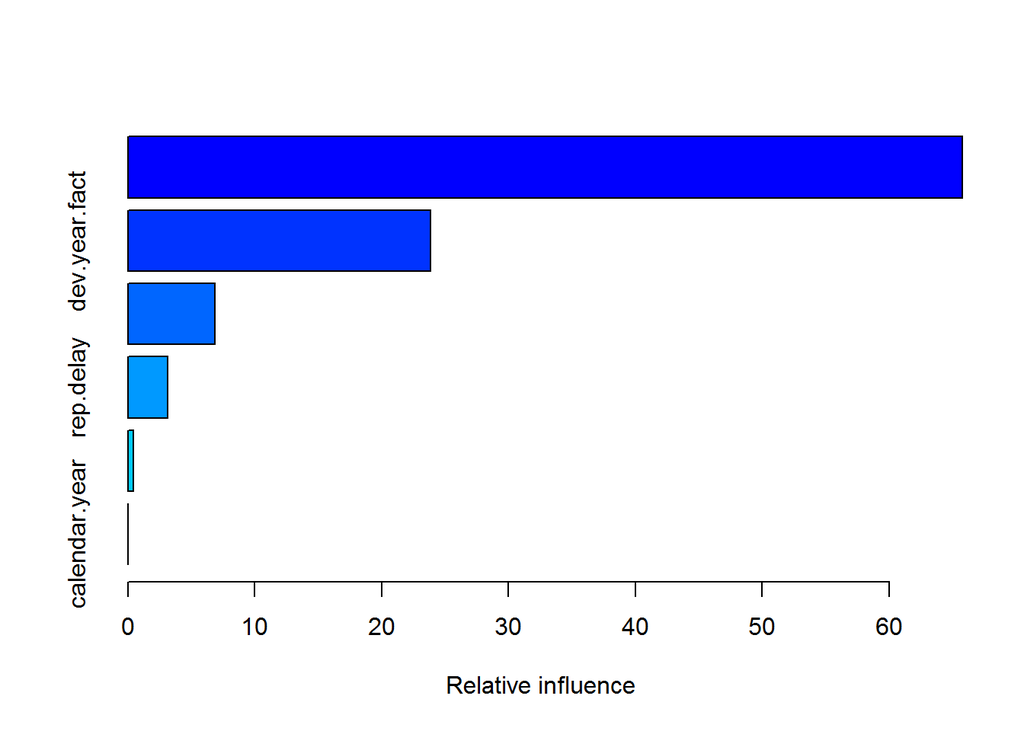

```
##                         var    rel.inf
## type                   type 65.7604816
## dev.year.fact dev.year.fact 23.8220721
## rep.month         rep.month  6.8528219
## rep.delay         rep.delay  3.1164345
## rep.year.fact rep.year.fact  0.4481899
## calendar.year calendar.year  0.0000000
```

```r
# Variable importance
summary(model_gbm$layers$settlement$fit)
```

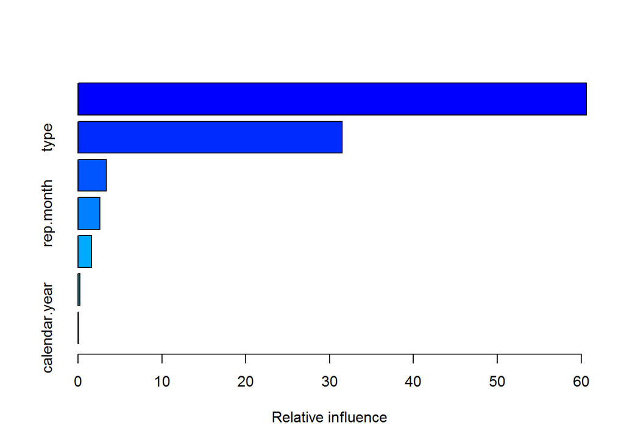

```
##                         var     rel.inf
## settlement       settlement 60.61384715
## type                   type 31.52264936
## dev.year.fact dev.year.fact  3.36880765
## rep.month         rep.month  2.62701115
## rep.delay         rep.delay  1.58870341
## rep.year.fact rep.year.fact  0.22857502
## calendar.year calendar.year  0.05040627
```

```r
# Variable importance
summary(model_gbm$layers$payment$fit)
```

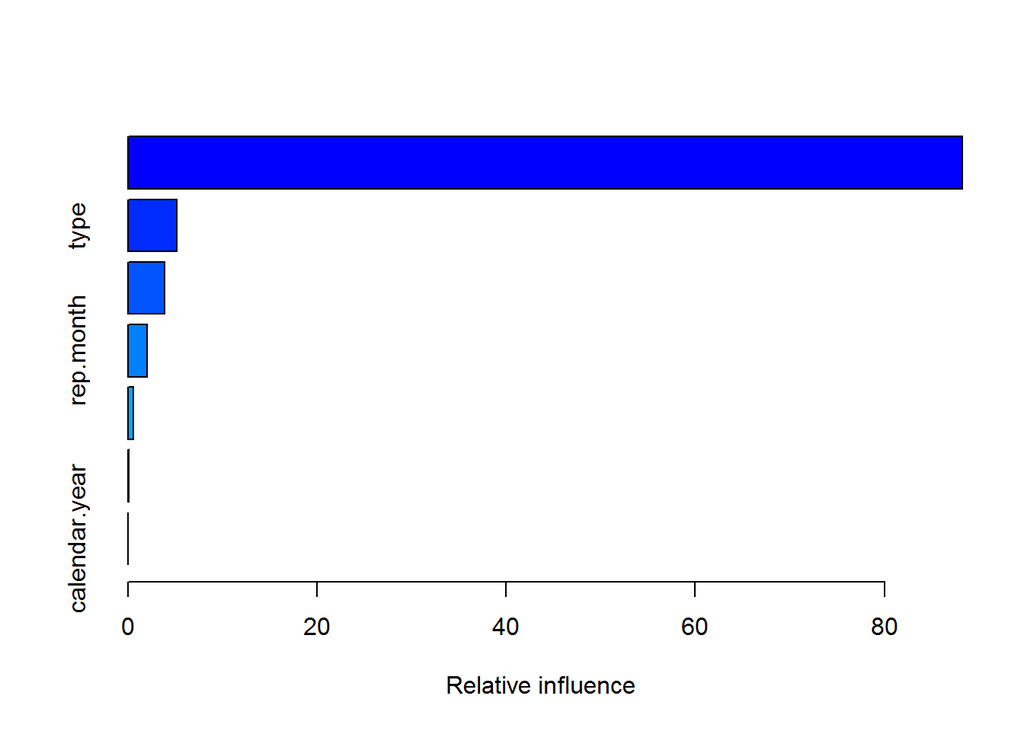

```
##                         var     rel.inf
## dev.year.fact dev.year.fact 88.24054388
## type                   type  5.15755472
## settlement       settlement  3.88718989
## rep.month         rep.month  1.99019655
## rep.delay         rep.delay  0.60847476
## rep.year.fact rep.year.fact  0.10180473
## calendar.year calendar.year  0.01423547
```

```r
# Variable importance
summary(model_gbm$layers$size$fit)
```

### Hierarchical XGB

We first define the model specifications of each layer. We only train the reserving model on the claim updates that are still open at the beginning of each year and are observed on the evaluation date (`calendar.year <= 9`).

Hyper parameters have been tuned in a previous stage.

```r
# Results of hierarchical model calibration
xgb_param_settle <- list('eta' =   .1, 'max_depth' = 1, 'nrounds' =  468, 'subsample' = 1)
xgb_param_pay    <- list('eta' =  .3, 'max_depth' = 2, 'nrounds' =  34, 'subsample' = 1)
xgb_param_size   <- list('eta' = .2, 'max_depth' = 1, 'nrounds' = 311, 'subsample' = 1)

# Model specifications
model_xgb <- hirem(reserving_data) %>%
  split_data(observed = function(df) df %>% filter(calendar.year <= 9, open == 1)) %>%
  layer_xgb('settlement', objective = 'binary:logistic', eval_metric = 'logloss', grow_policy = 'lossguide',
            eta = xgb_param_settle$eta, max_depth = xgb_param_settle$max_depth,
            nrounds = xgb_param_settle$nrounds, subsample = xgb_param_settle$subsample) %>%
  layer_xgb('payment', objective = 'binary:logistic', eval_metric = 'logloss', grow_policy = 'lossguide',
            eta = xgb_param_pay$eta, max_depth = xgb_param_pay$max_depth,
            nrounds = xgb_param_pay$nrounds, subsample = xgb_param_pay$subsample) %>%
  layer_xgb('size', objective = 'reg:gamma',
            eval_metric = 'gamma-deviance', grow_policy = 'lossguide',
            eta = xgb_param_size$eta, max_depth = xgb_param_size$max_depth,
            nrounds = xgb_param_size$nrounds, subsample = xgb_param_size$subsample,
            filter = function(data){data$payment == 1})
```

We now fit the hierarchical XGB on the observed portfolio of simulated claims.

```r
# Covariates
covariates_xgb <- c('type', 'dev.year.fact', 'rep.month', 'rep.year.fact', 'rep.delay', 'calendar.year')

# Fitting the hierarchical XGB
model_xgb <- hirem::fit(model_xgb,
                        weights = weight,
                        weight.var = 'dev.year',
                        balance.var = 'dev.year',
                        settlement = paste0('settlement ~ ', paste0(covariates_xgb, collapse = ' + ')) ,
                        payment = paste0('payment ~ ', paste0(c(covariates_xgb, 'settlement'), collapse = ' + ')),
                        size = paste0('size ~ ', paste0(c(covariates_xgb,'settlement'), collapse = ' + ')))
```

[output not shown]

We can obtain the cross-validation results as follows:

```r
if(!is.null(model_xgb$layers$settlement$hyper_grid)) model_xgb$layers$settlement$hyper_grid
if(!is.null(model_xgb$layers$payment$hyper_grid)) model_xgb$layers$payment$hyper_grid
if(!is.null(model_xgb$layers$size$hyper_grid)) model_xgb$layers$size$hyper_grid
```

```r
# Variable importance
xgb.importance(colnames(model_xgb$layers$settlement$fit), model = model_xgb$layers$settlement$fit)
```

```
##              Feature         Gain       Cover   Frequency
##  1:          type_T3 0.4823010032 0.081660113 0.079059829
##  2:          type_T1 0.2880189802 0.074326023 0.072649573
##  3: dev.year.fact_X8 0.0499969100 0.038724858 0.038461538
##  4: dev.year.fact_X9 0.0409098815 0.038569224 0.038461538
##  5: dev.year.fact_X2 0.0344931375 0.049098054 0.049145299
##  6: dev.year.fact_X3 0.0332102219 0.049091798 0.049145299
##  7: dev.year.fact_X7 0.0244515832 0.034142783 0.034188034
##  8:        rep.delay 0.0143763804 0.364731876 0.367521368
##  9: dev.year.fact_X4 0.0120318580 0.038301024 0.038461538
## 10:    rep.month_X11 0.0047606085 0.029746936 0.029914530
## 11:     rep.month_X4 0.0047116314 0.031867124 0.032051282
## 12:    calendar.year 0.0025571350 0.036075476 0.036324786
## 13: rep.year.fact_X1 0.0022710630 0.025471385 0.025641026
## 14:     rep.month_X3 0.0014522220 0.021222221 0.021367521
## 15: rep.year.fact_X2 0.0014411675 0.023340399 0.023504274
## 16: rep.year.fact_X5 0.0013019711 0.012740193 0.012820513
## 17: dev.year.fact_X6 0.0004337169 0.010604559 0.010683761
## 18:    rep.month_X10 0.0004151566 0.010604387 0.010683761
## 19:     rep.month_X5 0.0003208440 0.010600806 0.010683761
## 20:     rep.month_X2 0.0002341798 0.008479902 0.008547009
## 21:     rep.month_X9 0.0002087017 0.006361376 0.006410256
## 22: rep.year.fact_X8 0.0001016467 0.004239485 0.004273504
##              Feature         Gain       Cover   Frequency
```

```r
# Variable importance
xgb.importance(colnames(model_xgb$layers$payment$fit), model = model_xgb$layers$payment$fit)
```

```
##              Feature         Gain        Cover  Frequency
##  1:       settlement 0.5989830397 0.2184544903 0.15841584
##  2:          type_T3 0.2075296991 0.0961841715 0.09900990
##  3:          type_T1 0.1371659442 0.1131498915 0.09900990
##  4:        rep.delay 0.0171246794 0.2796821077 0.33663366
##  5: dev.year.fact_X2 0.0167133334 0.0874248598 0.06930693
##  6:    rep.month_X12 0.0127456621 0.0063365313 0.03960396
##  7: dev.year.fact_X9 0.0050494580 0.0701916471 0.06930693
##  8:    rep.month_X11 0.0021380273 0.0109579441 0.01980198
##  9: dev.year.fact_X7 0.0007732401 0.0424889418 0.02970297
## 10:     rep.month_X2 0.0007024319 0.0115548788 0.01980198
## 11:     rep.month_X3 0.0004089406 0.0265022535 0.01980198
## 12:     rep.month_X8 0.0002491682 0.0085474935 0.00990099
## 13: rep.year.fact_X2 0.0002157470 0.0282131945 0.01980198
## 14: rep.year.fact_X1 0.0002006291 0.0003115946 0.00990099
```

```r
# Variable importance
xgb.importance(colnames(model_xgb$layers$size$fit), model = model_xgb$layers$size$fit)
```

```
##              Feature         Gain        Cover   Frequency
##  1: dev.year.fact_X9 0.2423149132 5.425406e-03 0.090614887
##  2: dev.year.fact_X2 0.1644655328 1.647302e-01 0.080906149
##  3: dev.year.fact_X3 0.1434136091 3.011607e-03 0.035598706
##  4: dev.year.fact_X8 0.1261114006 1.564969e-03 0.064724919
##  5: dev.year.fact_X7 0.0722746753 1.305711e-03 0.055016181
##  6: dev.year.fact_X4 0.0586457974 6.282231e-04 0.025889968
##  7:    calendar.year 0.0450189537 1.779289e-01 0.051779935
##  8:       settlement 0.0412343076 1.376158e-03 0.058252427
##  9:          type_T3 0.0284471877 8.409249e-04 0.035598706
## 10:          type_T1 0.0230958199 8.405173e-04 0.035598706
## 11: dev.year.fact_X6 0.0172089531 9.930505e-04 0.042071197
## 12: rep.year.fact_X1 0.0117814295 2.298648e-04 0.009708738
## 13:        rep.delay 0.0054271612 6.349376e-01 0.152103560
## 14:    rep.month_X12 0.0053385696 5.346901e-04 0.022653722
```

[output cut: 16 more lines]

### Hierarchical Deep feed-forward Neural Network

We will use the gamma deviance as custom loss function and metric in `keras`:

```r
gamma_deviance_keras <- function(yobs, yhat) {
  K <- backend()
  2*K$mean((yobs-yhat)/yhat - K$log(yobs/yhat))
}

metric_gamma_deviance_keras <- keras::custom_metric("gamma_deviance_keras", function(yobs, yhat) {
  gamma_deviance_keras(yobs, yhat)
})
```

We first define the model specifications of each layer. We only train the reserving model on the claim updates that are still open at the beginning of each year and are observed on the evaluation date (`calendar.year <= 9`). The parameters were tuned in an earlier stage by means of a 5-fold cross-validation.

```r
# Model specifications
model_dnn <-  hirem(reserving_data) %>%
  split_data(observed = function(df) df %>% filter(calendar.year <= 9, open == 1)) %>%
  layer_dnn('settlement', distribution = 'bernoulli',
            bias_regularization = T,
            hidden = c(30,30,40),
            loss = 'binary_crossentropy',
            metrics = 'binary_crossentropy',
            optimizer = optimizer_nadam(),
            validation_split = .3,
            activation.output = 'sigmoid',
            family_for_init = binomial(), # default link = logit
            epochs = 100,
            batch_size = 1000,
            monitor = 'val_binary_crossentropy',
            patience = 20) %>%
  layer_dnn('payment', distribution = 'bernoulli',
            bias_regularization = T,
            hidden = c(40,30,20),
            loss = 'binary_crossentropy',
            metrics = 'binary_crossentropy',
            optimizer = optimizer_nadam(),
            validation_split = .3,
            activation.output = 'sigmoid',
            family_for_init = binomial(), # default link = logit
            epochs = 100,
            batch_size = 1000,
            monitor = 'val_binary_crossentropy',
            patience = 20) %>%
  layer_dnn('size', distribution = 'gamma',
            bias_regularization = T,
            hidden = c(20,20,30),
            loss = gamma_deviance_keras,
            metrics = metric_gamma_deviance_keras,
            optimizer = optimizer_nadam(),
            validation_split = .3,
            activation.output = 'exponential',
            family_for_init = Gamma(link=log), # default link = inverse
            epochs = 100,
            batch_size = 1000,
            monitor = 'val_gamma_deviance_keras',
            patience = 20,
            filter = function(data){data$payment == 1})
```

We now fit the hierarchical MLP on the observed portfolio of simulated claims.

```r
# Covariates
covariates_dnn <- c('type', 'dev.year.fact', 'rep.month', 'rep.year.fact', 'rep.delay', 'calendar.year')

# Fitting the hierarchical MLP
model_dnn <- hirem::fit(model_dnn,
                        balance.var = 'dev.year',
                        settlement = paste0('settlement ~ ', paste0(covariates_dnn, collapse = ' + ')),
                        payment = paste0('payment ~ ', paste0(c(covariates_dnn, 'settlement'), collapse = ' + ')),
                        size = paste0('size ~ ', paste0(c(covariates_dnn,'settlement'), collapse = ' + ')))
```

```
## Fitting layer_dnn for settlement...
## Model: "model_126"
## ___________________________________________________________________________________________________________________________________
##  Layer (type)                                             Output Shape                                         Param #
## ===================================================================================================================================
##  input_layer_nn (InputLayer)                              [(None, 35)]                                         0
##  hidden_layer_1 (Dense)                                   (None, 30)                                           1080
##  hidden_layer_activation_1 (Activation)                   (None, 30)                                           0
##  hidden_layer_2 (Dense)                                   (None, 30)                                           930
##  hidden_layer_activation_2 (Activation)                   (None, 30)                                           0
##  last_hidden_layer (Dense)                                (None, 40)                                           1240
##  last_hidden_layer_activation (Activation)                (None, 40)                                           0
##  output_layer (Dense)                                     (None, 1)                                            41
## ===================================================================================================================================
## Total params: 3,291
## Trainable params: 3,291
## Non-trainable params: 0
## ___________________________________________________________________________________________________________________________________
## [1] "Model: \"model_126\"\n___________________________________________________________________________________________________________________________________\n Layer (type)                                             Output Shape                                         Param #             \n====…
## Fitting layer_dnn for payment...
## Model: "model_128"
## ___________________________________________________________________________________________________________________________________
##  Layer (type)                                             Output Shape                                         Param #
## ===================================================================================================================================
##  input_layer_nn (InputLayer)                              [(None, 36)]                                         0
##  hidden_layer_1 (Dense)                                   (None, 40)                                           1480
##  hidden_layer_activation_1 (Activation)                   (None, 40)                                           0
##  hidden_layer_2 (Dense)                                   (None, 30)                                           1230
##  hidden_layer_activation_2 (Activation)                   (None, 30)                                           0
##  last_hidden_layer (Dense)                                (None, 20)                                           620
##  last_hidden_layer_activation (Activation)                (None, 20)                                           0
##  output_layer (Dense)                                     (None, 1)                                            21
## ===================================================================================================================================
## Total params: 3,351
## Trainable params: 3,351
## Non-trainable params: 0
## ___________________________________________________________________________________________________________________________________
## [1] "Model: \"model_128\"\n___________________________________________________________________________________________________________________________________\n Layer (type)                                             Output Shape                                         Param #             \n====…
```

[output cut: 19 more lines]

### Hierarchical Combined Actuarial Neural Network

We first define the model specifications of each layer. We only train the reserving model on the claim updates that are still open at the beginning of each year and are observed on the evaluation date (`calendar.year <= 9`). The parameters were tuned in an earlier stage by means of a 5-fold cross-validation.

```r
# Model specifications
model_cann <-  hirem(reserving_data) %>%
  split_data(observed = function(df) df %>% filter(calendar.year <= 9, open == 1)) %>%
  layer_cann('settlement', distribution = 'bernoulli',
             hidden = c(40,30,20),
             formula.glm = formula_settle_glm,
             bias_regularization = T,
             family_for_glm = binomial(),
             loss = 'binary_crossentropy',
             metrics = 'binary_crossentropy',
             optimizer = optimizer_nadam(),
             validation_split = .3,
             activation.output = 'linear',
             activation.output.cann = 'sigmoid',
             fixed.cann = T,
             monitor = 'val_binary_crossentropy',
             patience = 20,
             epochs = 100,
             batch_size = 1000) %>%
  layer_cann('payment', distribution = 'bernoulli',
             hidden = c(40,10,10),
             formula.glm = formula_pay_glm,
             bias_regularization = T,
             family_for_glm = binomial(),
             loss = 'binary_crossentropy',
             metrics = 'binary_crossentropy',
             optimizer = optimizer_nadam(),
             validation_split = .3,
             activation.output = 'linear',
             activation.output.cann = 'sigmoid',
             fixed.cann = T,
             monitor = 'val_binary_crossentropy',
             patience = 20,
             epochs = 100,
             batch_size = 1000) %>%
  layer_cann('size', distribution = 'gamma',
             hidden = c(20,10,10),
             formula.glm = formula_size_glm,
             bias_regularization = T,
             family_for_glm = Gamma(link=log),
             loss = gamma_deviance_keras,
             metrics = metric_gamma_deviance_keras,
             optimizer = optimizer_nadam(),
             validation_split = .3,
             activation.output = 'linear',
             activation.output.cann = 'exponential',
             fixed.cann = T,
             monitor = 'val_gamma_deviance_keras',
             patience = 20,
             epochs = 100,
             batch_size = 1000,
             filter = function(data){data$payment == 1})
```

We now fit the hierarchical CANN on the observed portfolio of simulated claims.

```r
#Covariates
covariates_cann <- c('type', 'dev.year.fact', 'rep.month', 'rep.year.fact', 'rep.delay', 'calendar.year')

# Fitting the hierarchical CANN
model_cann <- hirem::fit(model_cann,
                 balance.var = 'dev.year',
                 settlement = paste0('settlement ~ ', paste0(covariates_cann, collapse = ' + ')),
                 payment = paste0('payment ~ ', paste0(c(covariates_cann, 'settlement'), collapse = ' + ')),
                 size = paste0('size ~ ', paste0(c(covariates_cann,'settlement'), collapse = ' + ')))
```

```
## Fitting layer_cann for settlement...
## Model: "CANN"
## ___________________________________________________________________________________________________________________________________
##  Layer (type)                          Output Shape               Param #       Connected to                            Trainable
## ===================================================================================================================================
##  input_layer_nn (InputLayer)           [(None, 35)]               0             []                                      Y
##  hidden_layer_1 (Dense)                (None, 40)                 1440          ['input_layer_nn[0][0]']                Y
##  hidden_layer_activation_1 (Activation  (None, 40)                0             ['hidden_layer_1[0][0]']                Y
##  )
##  hidden_layer_2 (Dense)                (None, 30)                 1230          ['hidden_layer_activation_1[0][0]']     Y
##  hidden_layer_activation_2 (Activation  (None, 30)                0             ['hidden_layer_2[0][0]']                Y
##  )
##  last_hidden_layer (Dense)             (None, 20)                 620           ['hidden_layer_activation_2[0][0]']     Y
##  input_layer_glm (InputLayer)          [(None, 54)]               0             []                                      Y
##  last_hidden_layer_activation (Activat  (None, 20)                0             ['last_hidden_layer[0][0]']             Y
##  ion)
##  output_layer_glm (Dense)              (None, 1)                  55            ['input_layer_glm[0][0]']               N
##  output_layer_NN (Dense)               (None, 1)                  21            ['last_hidden_layer_activation[0][0]']  Y
##  add_42 (Add)                          (None, 1)                  0             ['output_layer_glm[0][0]',              Y
##                                                                                  'output_layer_NN[0][0]']
##  output_layer_CANN (Dense)             (None, 1)                  2             ['add_42[0][0]']                        N
## ===================================================================================================================================
## Total params: 3,368
## Trainable params: 3,311
## Non-trainable params: 57
## ___________________________________________________________________________________________________________________________________
## [1] "Model: \"CANN\"\n___________________________________________________________________________________________________________________________________\n Layer (type)                          Output Shape               Param #       Connected to                            Trainable  \n=========…
## Fitting layer_cann for payment...
## Model: "CANN"
## ___________________________________________________________________________________________________________________________________
##  Layer (type)                          Output Shape               Param #       Connected to                            Trainable
## ===================================================================================================================================
##  input_layer_nn (InputLayer)           [(None, 36)]               0             []                                      Y
##  hidden_layer_1 (Dense)                (None, 40)                 1480          ['input_layer_nn[0][0]']                Y
##  hidden_layer_activation_1 (Activation  (None, 40)                0             ['hidden_layer_1[0][0]']                Y
##  )
##  hidden_layer_2 (Dense)                (None, 10)                 410           ['hidden_layer_activation_1[0][0]']     Y
##  hidden_layer_activation_2 (Activation  (None, 10)                0             ['hidden_layer_2[0][0]']                Y
##  )
##  last_hidden_layer (Dense)             (None, 10)                 110           ['hidden_layer_activation_2[0][0]']     Y
```

[output cut: 26 more lines]

```
##  last_hidden_layer (Dense)             (None, 10)                 110           ['hidden_layer_activation_2[0][0]']     Y
##  input_layer_glm (InputLayer)          [(None, 55)]               0             []                                      Y
##  last_hidden_layer_activation (Activat  (None, 10)                0             ['last_hidden_layer[0][0]']             Y
##  ion)
##  output_layer_glm (Dense)              (None, 1)                  56            ['input_layer_glm[0][0]']               N
##  output_layer_NN (Dense)               (None, 1)                  11            ['last_hidden_layer_activation[0][0]']  Y
##  add_44 (Add)                          (None, 1)                  0             ['output_layer_glm[0][0]',              Y
##                                                                                  'output_layer_NN[0][0]']
##  output_layer_CANN (Dense)             (None, 1)                  2             ['add_44[0][0]']                        N
## ===================================================================================================================================
## Total params: 1,129
## Trainable params: 1,071
## Non-trainable params: 58
## ___________________________________________________________________________________________________________________________________
## [1] "Model: \"CANN\"\n___________________________________________________________________________________________________________________________________\n Layer (type)                          Output Shape               Param #       Connected to                            Trainable  \n=========…
```

We can obtain the cross-validation results (hypergrid case) as follows:

```r
if(!is.null(model_cann$layers$settlement$hyper_grid)) model_cann$layers$settlement$hyper_grid
if(!is.null(model_cann$layers$payment$hyper_grid)) model_cann$layers$payment$hyper_grid
if(!is.null(model_cann$layers$size$hyper_grid)) model_cann$layers$size$hyper_grid
```

We show the model retained:

```r
if(!is.null(model_cann$layers$settlement$fit.biased)) model_cann$layers$settlement$fit.biased
```

```
## Model: "CANN"
## ___________________________________________________________________________________________________________________________________
##  Layer (type)                          Output Shape               Param #       Connected to                            Trainable
## ===================================================================================================================================
##  input_layer_nn (InputLayer)           [(None, 35)]               0             []                                      Y
##  hidden_layer_1 (Dense)                (None, 40)                 1440          ['input_layer_nn[0][0]']                Y
##  hidden_layer_activation_1 (Activation  (None, 40)                0             ['hidden_layer_1[0][0]']                Y
##  )
##  hidden_layer_2 (Dense)                (None, 30)                 1230          ['hidden_layer_activation_1[0][0]']     Y
##  hidden_layer_activation_2 (Activation  (None, 30)                0             ['hidden_layer_2[0][0]']                Y
##  )
##  last_hidden_layer (Dense)             (None, 20)                 620           ['hidden_layer_activation_2[0][0]']     Y
##  input_layer_glm (InputLayer)          [(None, 54)]               0             []                                      Y
##  last_hidden_layer_activation (Activat  (None, 20)                0             ['last_hidden_layer[0][0]']             Y
##  ion)
##  output_layer_glm (Dense)              (None, 1)                  55            ['input_layer_glm[0][0]']               N
##  output_layer_NN (Dense)               (None, 1)                  21            ['last_hidden_layer_activation[0][0]']  Y
##  add_42 (Add)                          (None, 1)                  0             ['output_layer_glm[0][0]',              Y
##                                                                                  'output_layer_NN[0][0]']
##  output_layer_CANN (Dense)             (None, 1)                  2             ['add_42[0][0]']                        N
## ===================================================================================================================================
## Total params: 3,368
## Trainable params: 3,311
## Non-trainable params: 57
## ___________________________________________________________________________________________________________________________________
```

```r
if(!is.null(model_cann$layers$payment$fit.biased)) model_cann$layers$payment$fit.biased
```

```
## Model: "CANN"
## ___________________________________________________________________________________________________________________________________
##  Layer (type)                          Output Shape               Param #       Connected to                            Trainable
## ===================================================================================================================================
##  input_layer_nn (InputLayer)           [(None, 36)]               0             []                                      Y
##  hidden_layer_1 (Dense)                (None, 40)                 1480          ['input_layer_nn[0][0]']                Y
##  hidden_layer_activation_1 (Activation  (None, 40)                0             ['hidden_layer_1[0][0]']                Y
##  )
##  hidden_layer_2 (Dense)                (None, 10)                 410           ['hidden_layer_activation_1[0][0]']     Y
##  hidden_layer_activation_2 (Activation  (None, 10)                0             ['hidden_layer_2[0][0]']                Y
##  )
##  last_hidden_layer (Dense)             (None, 10)                 110           ['hidden_layer_activation_2[0][0]']     Y
##  input_layer_glm (InputLayer)          [(None, 55)]               0             []                                      Y
##  last_hidden_layer_activation (Activat  (None, 10)                0             ['last_hidden_layer[0][0]']             Y
##  ion)
##  output_layer_glm (Dense)              (None, 1)                  56            ['input_layer_glm[0][0]']               N
##  output_layer_NN (Dense)               (None, 1)                  11            ['last_hidden_layer_activation[0][0]']  Y
##  add_43 (Add)                          (None, 1)                  0             ['output_layer_glm[0][0]',              Y
##                                                                                  'output_layer_NN[0][0]']
##  output_layer_CANN (Dense)             (None, 1)                  2             ['add_43[0][0]']                        N
## ===================================================================================================================================
## Total params: 2,069
## Trainable params: 2,011
## Non-trainable params: 58
## ___________________________________________________________________________________________________________________________________
```

```r
if(!is.null(model_cann$layers$size$fit.biased)) model_cann$layers$size$fit.biased
```

```
## Model: "CANN"
## ___________________________________________________________________________________________________________________________________
##  Layer (type)                          Output Shape               Param #       Connected to                            Trainable
## ===================================================================================================================================
##  input_layer_nn (InputLayer)           [(None, 36)]               0             []                                      Y
##  hidden_layer_1 (Dense)                (None, 20)                 740           ['input_layer_nn[0][0]']                Y
##  hidden_layer_activation_1 (Activation  (None, 20)                0             ['hidden_layer_1[0][0]']                Y
##  )
##  hidden_layer_2 (Dense)                (None, 10)                 210           ['hidden_layer_activation_1[0][0]']     Y
##  hidden_layer_activation_2 (Activation  (None, 10)                0             ['hidden_layer_2[0][0]']                Y
##  )
##  last_hidden_layer (Dense)             (None, 10)                 110           ['hidden_layer_activation_2[0][0]']     Y
##  input_layer_glm (InputLayer)          [(None, 55)]               0             []                                      Y
##  last_hidden_layer_activation (Activat  (None, 10)                0             ['last_hidden_layer[0][0]']             Y
##  ion)
##  output_layer_glm (Dense)              (None, 1)                  56            ['input_layer_glm[0][0]']               N
##  output_layer_NN (Dense)               (None, 1)                  11            ['last_hidden_layer_activation[0][0]']  Y
##  add_44 (Add)                          (None, 1)                  0             ['output_layer_glm[0][0]',              Y
##                                                                                  'output_layer_NN[0][0]']
##  output_layer_CANN (Dense)             (None, 1)                  2             ['add_44[0][0]']                        N
## ===================================================================================================================================
## Total params: 1,129
## Trainable params: 1,071
## Non-trainable params: 58
## ___________________________________________________________________________________________________________________________________
```

## Predicting the future development of claims in the hierarchical reserving models

In the next step, we predict the future development of claims. We do this by simulating 50 different paths for each open claim in the year of the evaluation date and by averaging the results afterwards. In this prediction strategy, the hierarchical structure of the reserving model is preserved and the development of claims are simulated in chronological order.

We define an update function applied to the data for the simulation of each subsequent development year.

```r
# Update function
update <- function(data) {
  data$dev.year <- data$dev.year + 1
  data$dev.year.fact <- factor(data$dev.year, levels = 1:9)

  data$calendar.year <- data$calendar.year + 1

  data$monthDev12[data$dev.year > 3] <- 'dev.year.over.3'
  data$devYearMonth <- factor(paste(data$dev.year, data$monthDev12, sep = '-'))

  data
}

model_glm <- register_updater(model_glm, update)
model_gbm <- register_updater(model_gbm, update)
model_xgb <- register_updater(model_xgb, update)
model_dnn <- register_updater(model_dnn, update)
model_cann <- register_updater(model_cann, update)
```

Next, we apply the actual simulation of the development of claims over time beyond the observation window of those claims that are still open at the evaluation date (calendar year 9). Moreover, we apply the balance correction as explained in Creveceour, Antonio, and Robben (2021).

```r
nsim <- 50

simul_glm <- simulate(model_glm,
                      nsim = nsim,
                      filter = function(data){dplyr::filter(data, dev.year <= 9, settlement == 0)},
                      data = model_glm$data_observed %>% dplyr::filter(calendar.year == 9),
                      balance.correction = TRUE)

simul_gbm <- simulate(model_gbm,
                      nsim = nsim,
                      filter = function(data){dplyr::filter(data, dev.year <= 9, settlement == 0)},
                      data = model_gbm$data_observed %>% dplyr::filter(calendar.year == 9),
                      balance.correction = TRUE)

simul_xgb <- simulate(model_xgb,
                      nsim = nsim,
                      filter = function(data){dplyr::filter(data, dev.year <= 9, settlement == 0)},
                      data = model_xgb$data_observed %>% dplyr::filter(calendar.year == 9),
                      balance.correction = TRUE)
```

[output not shown]

```r
simul_dnn <- simulate(model_dnn,
                      nsim = nsim,
                      filter = function(data){dplyr::filter(data, dev.year <= 9, settlement == 0)},
                      data = model_dnn$data_observed %>% dplyr::filter(calendar.year == 9),
                      balance.correction = TRUE)

simul_cann <- simulate(model_cann,
                      nsim = nsim,
                      filter = function(data){dplyr::filter(data, dev.year <= 9, settlement == 0)},
                      data = model_cann$data_observed %>% dplyr::filter(calendar.year == 9),
                      balance.correction = TRUE)
```

## Chain-ladder model

For comparison, we apply the classical chain ladder model to predict the total number of open claims, the total number of payments and the total payment sizes outside the observation window.

We first construct the incremental run-off triangles for the number of open claims, the number of payments and the total payment sizes in each reporting year and development year since reporting in the observed portfolio. We know the number of open claims in the year following the evaluation date since we have information whether or not a claim settles in the year of settlement.

```r
# Incremental run-off triangles
triangle_open    <- construct_triangle(data = observed_data %>% filter(open == 1), group.var1 = 'rep.year',
                                       group.var2 = 'dev.year', value = 'open', cumulative = FALSE)
triangle_payment <- construct_triangle(data = observed_data, group.var1 = 'rep.year',
                                       group.var2 = 'dev.year', value = 'payment', cumulative = FALSE)
triangle_size    <- construct_triangle(data = observed_data, group.var1 = 'rep.year',
                                       group.var2 = 'dev.year', value = 'size', cumulative = FALSE)

# Number of open claims in the year following the evaluation date
settle.evalyear <- observed_data %>%
  filter(open == 1, calendar.year == 9) %>%
  group_by(rep.year, dev.year) %>%
  summarise(settlement = sum(settlement))

# The number of open claims in the year after the evaluation date
triangle_open[row(triangle_open) + col(triangle_open) == 11] <-
  (triangle_open[row(triangle_open) + col(triangle_open) == 10] - rev(settle.evalyear$settlement))[1:8]
```

We then apply (a special version of) the chain-ladder model on the incremental run-off triangle for the number of open claims. For the number of payments and the payment sizes, we use the classical chain ladder model applied on the cumulative run-off triangles.

```r
# Chain ladder predictions
cl_open <- chainLadder_open(triangle_open)
cl_pay  <- chainLadder(triangle_payment, is_cumulatif = FALSE)
cl_size <- chainLadder(triangle_size, is_cumulatif = FALSE)
```

First, we compare the prediction for the total number of open claims in the test set.

```r
nsim <- 50

# Predictions
obs_open_total <- prediction_data %>% filter(calendar.year != 10) %>% summarise(Total = sum(open)) %>% pull(Total)
cl_open_total  <- sum(cl_open)
glm_open_total <- simul_glm %>% filter(calendar.year != 10) %>% summarise(Total = sum(open)/nsim) %>% pull(Total)
gbm_open_total <- simul_gbm %>% filter(calendar.year != 10) %>% summarise(Total = sum(open)/nsim) %>% pull(Total)
xgb_open_total <- simul_xgb %>% filter(calendar.year != 10) %>% summarise(Total = sum(open)/nsim) %>% pull(Total)
dnn_open_total <- simul_dnn %>% filter(calendar.year != 10) %>% summarise(Total = sum(open)/nsim) %>% pull(Total)
cann_open_total <- simul_cann %>% filter(calendar.year != 10) %>% summarise(Total = sum(open)/nsim) %>% pull(Total)

# Print Results
c('Actual' =  obs_open_total, 'Chain-Ladder' = cl_open_total, 'Hierarchical GLM' = glm_open_total, 'Hierarchical GBM' = gbm_open_total, 'Hierarchical XGB' = xgb_open_total, 'Hierarchical DNN' = dnn_open_total, 'Hierarchical CANN' = cann_open_total)
```

```
##            Actual      Chain-Ladder  Hierarchical GLM  Hierarchical GBM  Hierarchical XGB  Hierarchical DNN Hierarchical CANN
##          58702.00          55082.96          57670.84          57709.88          57311.56          59658.84          56984.68
```

Second, we compare the prediction for the total number of payments in the prediction data set.

```r
# Predictions
obs_pay_total <- prediction_data %>% summarise(Total = sum(payment)) %>% pull(Total)
cl_pay_total  <- sum(cl_pay)
glm_pay_total <- simul_glm %>% summarise(Total = sum(payment)/nsim) %>% pull(Total)
gbm_pay_total <- simul_gbm %>% summarise(Total = sum(payment)/nsim) %>% pull(Total)
xgb_pay_total <- simul_xgb %>% summarise(Total = sum(payment)/nsim) %>% pull(Total)
dnn_pay_total <- simul_dnn %>% summarise(Total = sum(payment)/nsim) %>% pull(Total)
cann_pay_total <- simul_cann %>% summarise(Total = sum(payment)/nsim) %>% pull(Total)

# Print Results
c('Actual' = obs_pay_total, 'Chain-Ladder' = cl_pay_total, 'Hierarchical GLM' = glm_pay_total, 'Hierarchical GBM' = gbm_pay_total, 'Hierarchical XGB' = xgb_pay_total, 'Hierarchical DNN' = dnn_pay_total, 'Hierarchical CANN' = cann_pay_total)
```

```
##            Actual      Chain-Ladder  Hierarchical GLM  Hierarchical GBM  Hierarchical XGB  Hierarchical DNN Hierarchical CANN
##          58645.00          54756.14          57699.88          57862.20          57534.68          58288.04          57709.86
```

Third, we compare the prediction for the total number of payment sizes in the prediction set.

```r
# Predictions
obs_size_total <- prediction_data %>% summarise(Total = sum(size)) %>% pull(Total)
cl_size_total  <- sum(cl_size)
glm_size_total <- simul_glm %>% summarise(Total = sum(size)/nsim) %>% pull(Total)
gbm_size_total <- simul_gbm %>% summarise(Total = sum(size)/nsim) %>% pull(Total)
xgb_size_total <- simul_xgb %>% summarise(Total = sum(size)/nsim) %>% pull(Total)
dnn_size_total <- simul_dnn %>% summarise(Total = sum(size)/nsim) %>% pull(Total)
cann_size_total <- simul_cann %>% summarise(Total = sum(size)/nsim) %>% pull(Total)

# Print Results
c('Actual' = obs_size_total, 'Chain-Ladder' = cl_size_total, 'Hierarchical GLM' = glm_size_total, 'Hierarchical GBM' = gbm_size_total, 'Hierarchical XGB' = xgb_size_total, 'Hierarchical DNN' = dnn_size_total, 'Hierarchical CANN' = cann_size_total)
```

```
##            Actual      Chain-Ladder  Hierarchical GLM  Hierarchical GBM  Hierarchical XGB  Hierarchical DNN Hierarchical CANN
##          80958648          73753774          78538277          77999707          76894421          76749864          78035227
```

## References

Creveceour, Jonas, Katrien Antonio, and Jens Robben. 2021. “A Hierarchical Reserving Model for Reported Non-Life Insurance Claims.”